# **Abstract**

**This is quite a broad and in depth dataset, so for my project I would like to hone in on the specific goal of predicting a player's market value. I will accomplish this using a supervised machine learning approach applying regression algorithms. Data preprocessing steps will include handling missing values, scaling numerical features, and encoding categorical variables. Feature selection will be focused on the attributes deemed most relevant to a player's market value. Model evaluation will be based on metrics such as MSE and R-Squared.**

**The expected benefits of this project are very applicable in the real world, as it would allow a football team's manager or scouting department to locate undervalued football players and pursue them in hopes of bettering their squad, or potentially selling them on for profit in a few years.**

```python
!pip install pyspark
```

```
     ━━━━━━━━━━━━━━━━━━━━━━━━━━━━━━━━━━━━━━━ 317.3/317.3 MB 5.3 MB/s eta 0:00:00
  Preparing metadata (setup.py) ... - \ done
```

```python
from pyspark.sql import SparkSession


spark = SparkSession.builder.appName("FootballManager2020").getOrCreate()

data = (
    spark.read
    .csv("/kaggle/input/football-manager-2020/datafm20.csv", header=True, inferSchema=True)
    .drop("_c0")  # Drop the unnecessary column
)
# data.printSchema()
# data.show(5, truncate=False)
```

```
Setting default log level to "WARN".
To adjust logging level use sc.setLogLevel(newLevel). For SparkR, use setLogLevel(newLevel).
24/12/05 20:37:06 WARN NativeCodeLoader: Unable to load native-hadoop library for your platform... using builtin-java classes where applicable
```

```python
spark.sparkContext.setLogLevel("ERROR")  # Suppress INFO and WARN logs
```

```python
data.select("Value").describe().show()
```

```
[Stage 2:==============>                                            (1 + 3) / 4]
```

```
+-------+------------------+
|summary|             Value|
+-------+------------------+
|  count|            144750|
|   mean|350358.27074956824|
| stddev|2392352.3886146243|
|    min|                 0|
|    max|          91000000|
+-------+------------------+
```

```python
print(data.columns)
```

```
['Name', 'Position', 'Club', 'Division', 'Based', 'Nation', 'Height', 'Weight', 'Age', 'Preferred Foot', 'Best Pos', 'Best Role', 'Value', 'Wage', 'CA', 'PA', 'Wor', 'Vis', 'Thr', 'Tec', 'Tea', 'Tck', 'Str', 'Sta', 'TRO', 'Ref', 'Pun', 'Pos', 'Pen', 'Pas', 'Pac', '1v1', 'OtB', 'Nat', 'Mar', 'L Th', …
```

```python
import pandas as pd

# Display all columns
pd.set_option('display.max_columns', None)

# Then reprint the dataframe
print(data.head())
```

```
Row(Name='Lionel Messi', Position='AM (RC), ST (C)', Club='Barcelona', Division='Spanish First Division', Based='Spain (First Division)', Nation='ARG', Height=170, Weight=72, Age=32, Preferred Foot='Left', Best Pos='AM (R)', Best Role='IF', Value=73000000, Wage=1200000, CA=195, PA=200, Wor=7, Vis=20…
```

```python
zero_count = data.filter(data['Value'] == 0).count()
print(f"Number of zeros in the Value column: {zero_count}")
```

```
Number of zeros in the Value column: 35456
```

```python
non_zero_values = data[data['Value'] > 0]
```

```python
from pyspark.sql.functions import log10

# Add a new column 'LogValue' with the log10 of the 'Value' column
non_zero_values = non_zero_values.withColumn('LogValue', log10(non_zero_values['Value']))
```

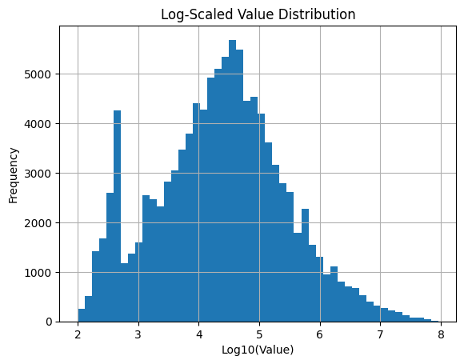

```python
# Convert the 'LogValue' column to Pandas
log_values = non_zero_values.select("LogValue").toPandas()

# Plot the histogram
import matplotlib.pyplot as plt

log_values['LogValue'].hist(bins=50)
plt.title('Log-Scaled Value Distribution')
plt.xlabel('Log10(Value)')
plt.ylabel('Frequency')
plt.show()
```

```python
from pyspark.sql.types import IntegerType, DoubleType
# Get the list of numerical columns (int and double types)
numerical_columns = [field.name for field in data.schema.fields if isinstance(field.dataType, (IntegerType, DoubleType))]

# Show the list of numerical columns
print("Numerical columns:", numerical_columns)
```

```
Numerical columns: ['Height', 'Weight', 'Age', 'Value', 'Wage', 'CA', 'PA', 'Wor', 'Vis', 'Thr', 'Tec', 'Tea', 'Tck', 'Str', 'Sta', 'TRO', 'Ref', 'Pun', 'Pos', 'Pen', 'Pas', 'Pac', '1v1', 'OtB', 'Nat', 'Mar', 'L Th', 'Lon', 'Ldr', 'Kic', 'Jum', 'Hea', 'Han', 'Fre', 'Fla', 'Fir', 'Fin', 'Ecc', 'Dri',…
```

```python
from pyspark.ml.stat import Correlation
from pyspark.ml.feature import VectorAssembler

# Assemble the numerical columns into a single feature vector
assembler = VectorAssembler(inputCols=numerical_columns, outputCol="features")

# Transform the data to assemble the features into a vector
data_with_features = assembler.transform(data)

# Compute the correlation matrix (Pearson correlation)
pearson_matrix = Correlation.corr(data_with_features, "features", "pearson").head()[0]

# Convert the correlation matrix to a NumPy array for easier manipulation
correlation_matrix = pearson_matrix.toArray()

# Convert the correlation matrix into a Pandas DataFrame for easier visualization
import pandas as pd
correlation_df = pd.DataFrame(correlation_matrix, columns=numerical_columns, index=numerical_columns)

# Display the correlation matrix
# print(correlation_df)
```

[figure not shown]

```python
import seaborn as sns
import matplotlib.pyplot as plt

# Plot the correlation matrix using Seaborn heatmap
plt.figure(figsize=(14, 12))
sns.heatmap(correlation_df, annot=True, cmap='coolwarm', vmin=-1, vmax=1, fmt='.2f', linewidths=0.5)
plt.title("Correlation Matrix of Numerical Features")
plt.show()
```

```python
from pyspark.sql.types import NumericType

# Identify numerical columns
numerical_columns = [field.name for field in data.schema.fields if isinstance(field.dataType, NumericType)]

# Compute correlations with 'Value'
correlations = []
for col in numerical_columns:
    if col != 'Value':  # Skip self-correlation
        corr_value = data.corr('Value', col)
        correlations.append((col, corr_value))

# Sort correlations by absolute value, descending
sorted_correlations = sorted(correlations, key=lambda x: abs(x[1]), reverse=True)

# Display the top 10 correlated features
print("Top 10 Features Correlated with Value:")
for feature, corr in sorted_correlations[:10]:
    print(f"{feature}: {corr:.3f}")
```

```
Top 10 Features Correlated with Value:
Wage: 0.763
CA: 0.327
PA: 0.286
Cmp: 0.215
Bal: 0.212
Tea: 0.208
Ant: 0.205
Cnt: 0.188
Pen: 0.184
Wor: 0.178
```

**Most Correlated Features with Value Explained:**

**Wage is obvious, as players worth a lot will be paid a lot.CA stands for Current Ability and PA stands for Potential Ability. These are also somewhat obvious although may be interesting to explore.The other's are all measures of the player's ability and style of play.Composure, Balance, Teamwork, Anticipation, Concentration, Penalty Taking, and Work Rate are the remaining top 10 attributes with the highest correlation to a player's Value.**

```python
# Load the data
data = spark.read.csv("/kaggle/input/football-manager-2020/datafm20.csv", header=True, inferSchema=True)

# Check the schema
# data.printSchema()

#Select the desired Features - Name, Value + The Top 10 Correlation with Value
selected_features = ['Name','Wage','Value', 'CA', 'PA', 'Cmp', 'Bal', 'Tea', 'Ant', 'Cnt', 'Pen', 'Wor', 'Position', 'Club']

# Select only the required columns
data = data.select(*selected_features)
```

```python
from pyspark.sql.functions import col, mean, when, count

# Check for missing values
data.select([count(when(col(c).isNull(), c)).alias(c) for c in data.columns]).show()

# Fill missing values for numerical columns with the mean
numerical_columns = ['Wage','CA', 'PA', 'Cmp', 'Bal', 'Tea', 'Ant', 'Cnt', 'Pen', 'Wor']
for col_name in numerical_columns:
    mean_value = data.select(mean(col(col_name))).collect()[0][0]
    data = data.fillna({col_name: mean_value})

# Fill missing values for categorical columns with mode
categorical_columns = ['Position', 'Club']
for col_name in categorical_columns:
    mode_value = data.groupBy(col_name).count().orderBy('count', ascending=False).first()[0]
    data = data.fillna({col_name: mode_value})
```

```
+----+----+-----+---+---+---+---+---+---+---+---+---+--------+----+
|Name|Wage|Value| CA| PA|Cmp|Bal|Tea|Ant|Cnt|Pen|Wor|Position|Club|
+----+----+-----+---+---+---+---+---+---+---+---+---+--------+----+
|   0|   0|    0|  0|  0|  0|  0|  0|  0|  0|  0|  0|       0|   0|
+----+----+-----+---+---+---+---+---+---+---+---+---+--------+----+
```

```python
print(data.columns)
```

```
['Name', 'Wage', 'Value', 'CA', 'PA', 'Cmp', 'Bal', 'Tea', 'Ant', 'Cnt', 'Pen', 'Wor', 'Position', 'Club']
```

```python
from pyspark.ml.feature import MinMaxScaler, StringIndexer, OneHotEncoder, VectorAssembler

# Scale numerical features
scaler_input = ['Wage','CA', 'PA', 'Cmp', 'Bal', 'Tea', 'Ant', 'Cnt', 'Pen', 'Wor']

# Drop the existing 'numerical_features' column if it exists
data = data.drop('numerical_features','scaled_features','Position_index','Club_index','Position_encoded', 'Club_encoded')

# Assemble the numerical features
assembler = VectorAssembler(inputCols=scaler_input, outputCol="numerical_features")
data = assembler.transform(data)

# Apply MinMaxScaler
scaler = MinMaxScaler(inputCol="numerical_features", outputCol="scaled_features")
scaler_model = scaler.fit(data)
data = scaler_model.transform(data)

# Encode categorical features
indexer = StringIndexer(inputCols=['Position', 'Club'], outputCols=['Position_index', 'Club_index'])
data = indexer.fit(data).transform(data)

encoder = OneHotEncoder(inputCols=['Position_index', 'Club_index'], outputCols=['Position_encoded', 'Club_encoded'])
data = encoder.fit(data).transform(data)
```

```python
# Split the data into train and test sets
train_data, test_data = data.randomSplit([0.8, 0.2], seed=42)
# Drop rows where the Value is 0
train_data = train_data.filter(train_data['Value'] != 0)
test_data = test_data.filter(test_data['Value'] != 0)

print(f"Number of records in the training set: {train_data.count()}")
print(f"Number of records in the test set: {test_data.count()}")
```

```
Number of records in the training set: 87561
```

```
[Stage 223:==============>                                          (1 + 3) / 4]
```

```
Number of records in the test set: 21733
```

```python
# Specify the features to be included in the model
feature_cols = ['Wage','CA', 'PA', 'Cmp', 'Bal', 'Tea', 'Ant', 'Cnt', 'Pen', 'Wor', 'Position_encoded', 'Club_encoded']

# Drop the existing features column if it exists
train_data = train_data.drop("features")
test_data = test_data.drop("features")

# Now, transform the data with the VectorAssembler
assembler = VectorAssembler(inputCols=feature_cols, outputCol="features")
train_data = assembler.transform(train_data)
test_data = assembler.transform(test_data)
```

```python
from pyspark.ml.regression import LinearRegression

# Initialize the linear regression model
lr = LinearRegression(featuresCol="features", labelCol="Value")

# Train the model on the training data
lr_model = lr.fit(train_data)

# Make predictions on the test data
predictions = lr_model.transform(test_data)

# Show some predictions
predictions.select("prediction", "Value", "features").show(5)
```

```
+------------------+-------+--------------------+
|        prediction|  Value|            features|
+------------------+-------+--------------------+
| 1070740.790772777| 950000|(11041,[0,1,2,3,4...|
|1545588.3505799375|3100000|(11041,[0,1,2,3,4...|
| 335670.2757558909| 160000|(11041,[0,1,2,3,4...|
| 750815.8344279102| 375000|(11041,[0,1,2,3,4...|
|-288533.0642323112| 225000|(11041,[0,1,2,3,4...|
+------------------+-------+--------------------+
only showing top 5 rows
```

```python
# Evaluate the model's performance using R-squared and MSE
from pyspark.ml.evaluation import RegressionEvaluator

# Initialize the evaluator
evaluator = RegressionEvaluator(labelCol="Value", predictionCol="prediction", metricName="rmse")

# Calculate RMSE
rmse = evaluator.evaluate(predictions)
print(f"Root Mean Squared Error (RMSE): {rmse}")

# Calculate R-squared
r2_evaluator = RegressionEvaluator(labelCol="Value", predictionCol="prediction", metricName="r2")
r2 = r2_evaluator.evaluate(predictions)
print(f"R-squared: {r2}")
```

```
Root Mean Squared Error (RMSE): 1713698.3712481041
```

```
[Stage 268:==============>                                          (1 + 3) / 4]
```

```
R-squared: 0.6051067298676986
```

```python
from pyspark.ml.tuning import ParamGridBuilder, CrossValidator
from pyspark.ml.evaluation import RegressionEvaluator

# Set up parameter grid for tuning
param_grid = (ParamGridBuilder()
              .addGrid(lr.regParam, [0.2, 0.01])
              .addGrid(lr.maxIter, [10, 40])
              .build())

# Initialize cross-validation
cross_val = CrossValidator(estimator=lr,
                           estimatorParamMaps=param_grid,
                           evaluator=RegressionEvaluator(labelCol="Value", predictionCol="prediction", metricName="rmse"),
                           numFolds=3)  # 3-fold cross-validation

# Train the model using cross-validation
cv_model = cross_val.fit(train_data)

# Get the best model
best_model = cv_model.bestModel

# Make predictions with the best model
predictions = best_model.transform(test_data)

# Show predictions
predictions.select("prediction", "Value", "features").show(5)
```

```
+-------------------+-------+--------------------+
|         prediction|  Value|            features|
+-------------------+-------+--------------------+
| 1070740.9419483438| 950000|(11041,[0,1,2,3,4...|
|  1545588.189194258|3100000|(11041,[0,1,2,3,4...|
| 335670.52887778566| 160000|(11041,[0,1,2,3,4...|
|  750815.7200906815| 375000|(11041,[0,1,2,3,4...|
|-288532.88244057156| 225000|(11041,[0,1,2,3,4...|
+-------------------+-------+--------------------+
only showing top 5 rows
```

```python
# Initialize the evaluator
evaluator = RegressionEvaluator(labelCol="Value", predictionCol="prediction", metricName="rmse")

# Calculate RMSE for the best model
rmse = evaluator.evaluate(predictions)
print(f"Root Mean Squared Error (RMSE) with Cross-Validation: {rmse}")

# Calculate R-squared for the best model
r2_evaluator = RegressionEvaluator(labelCol="Value", predictionCol="prediction", metricName="r2")
r2 = r2_evaluator.evaluate(predictions)
print(f"R-squared with Cross-Validation: {r2}")
```

```
Root Mean Squared Error (RMSE) with Cross-Validation: 1713698.326279575
```

```
[Stage 663:==============>                                          (1 + 3) / 4]
```

```
R-squared with Cross-Validation: 0.6051067505921965
```

```python
print(f"Best regParam: {cv_model.bestModel._java_obj.getRegParam()}")
print(f"Best maxIter: {cv_model.bestModel._java_obj.getMaxIter()}")
```

```
Best regParam: 0.2
Best maxIter: 40
```

```python
from pyspark.sql import SparkSession
from pyspark.sql.functions import col

# Initialize Spark session
spark = SparkSession.builder.appName("FootballModel").getOrCreate()

# Load the original dataset (datafm20.csv)
original_data = spark.read.csv("/kaggle/input/football-manager-2020/datafm20.csv", header=True, inferSchema=True)

# Rename conflicting columns in the original_data DataFrame
original_data = original_data.withColumnRenamed("Value", "Original_Value")
```

```python
from pyspark.sql.functions import col, when

# Deduplicate original_data and predictions
original_data = original_data.dropDuplicates(["Name"])
predictions = predictions.dropDuplicates(["Name"])

# Join predictions with original_data
predictions_with_names = predictions.join(original_data, on="Name", how="inner")

# Calculate value_diff only for cases where prediction > Original_Value
predictions_with_names = predictions_with_names.withColumn(
    "value_diff",
    when(col("prediction") > col("Original_Value"), col("prediction") - col("Original_Value")).otherwise(0)
)

# Filter players where value_diff > 0 to only include undervalued players
undervalued_players = predictions_with_names.filter(col("value_diff") > 0)

# Sort by value_diff in descending order
undervalued_players = undervalued_players.orderBy(col("value_diff").desc())

# Show top 5 undervalued players
undervalued_players.select("Name","Age", "Original_Value", "prediction", "value_diff").show(5)
```

```
+-----------------+---+--------------+--------------------+--------------------+
|             Name|Age|Original_Value|          prediction|          value_diff|
+-----------------+---+--------------+--------------------+--------------------+
|Cristiano Ronaldo| 34|      31000000|1.5770627261671144E8|1.2670627261671144E8|
|            Oscar| 27|      39000000| 8.878890588550171E7| 4.978890588550171E7|
|Marouane Fellaini| 31|      16500000|  5.72574927739364E7|  4.07574927739364E7|
|    Sandro Wagner| 31|      10000000| 4.005055172900196E7| 3.005055172900196E7|
|   Lukas Podolski| 34|       1700000|2.3497449758468855E7|2.1797449758468855E7|
+-----------------+---+--------------+--------------------+--------------------+
only showing top 5 rows
```

**A lot of these players are seen as higher value than they actually are, because they are aging and therefore have less time left in their careers. I want to discover younger players who may be getting overlooked and undervalued. Therefore I added in a filter for players under 25 for my final list.**

```python
# Filter for players under the age of 25
undervalued_players = undervalued_players.filter(col("Age") < 25)

# Sort by value_diff in descending order
undervalued_players = undervalued_players.orderBy(col("value_diff").desc())

# Show top 20 undervalued players
undervalued_players.select("Name", "Age", "Original_Value", "prediction", "value_diff").show(20)
```

```
+------------------+---+--------------+--------------------+--------------------+
|              Name|Age|Original_Value|          prediction|          value_diff|
+------------------+---+--------------+--------------------+--------------------+
|  Lucas HernÃ¡ndez| 23|      29500000|4.6392021198321484E7|1.6892021198321484E7|
|  Marcelo Pitaluga| 16|        165000|1.3931798437178236E7|1.3766798437178236E7|
|         Jake Cain| 17|         47500|1.0488042219873093E7|1.0440542219873093E7|
|      Paul Glatzel| 18|        110000|1.0250455533435848E7|1.0140455533435848E7|
|        Ben Knight| 17|        130000|   9916124.404704016|   9786124.404704016|
|      James Norris| 16|         36000|   9760588.226749558|   9724588.226749558|
|      Felix Nmecha| 18|        725000|1.0276954777679665E7|   9551954.777679665|
|       Sean Wilson| 16|          8500|   9310121.371652769|   9301621.371652769|
|    Jamie Lawrence| 16|         54000|   9196320.529348165|   9142320.529348165|
|     Malik Tillman| 17|         54000|   9122304.526589233|   9068304.526589233|
|    Dennis Waidner| 18|         88000|   9143888.557836713|   9055888.557836713|
|      Ben Woodburn| 19|       3400000| 1.241899029829026E7|    9018990.29829026|
|        Oscar Bobb| 15|         90000|   9049213.180784998|   8959213.180784998|
|      Finley Burns| 16|         45000|   8921888.913334763|   8876888.913334763|
|      James McAtee| 16|         50000|   8845395.874691974|   8795395.874691974|
|      Armindo Sieb| 16|           500|   8784658.401708879|   8784158.401708879|
|     Jamal Musiala| 16|       1100000|   9876646.615296282|   8776646.615296282|
|Pervis EstupiÃ±Ã¡n| 21|        800000|   9350874.168402724|   8550874.168402724|
|             Bruma| 24|       2400000| 1.043151421040827E7|    8031514.21040827|
| Richairo Zivkovic| 22|       5500000|1.3332086520147007E7|   7832086.520147007|
+------------------+---+--------------+--------------------+--------------------+
only showing top 20 rows
```

# **Limitations**

**This Dataset is from the 2020 edition of the game, so these players are now four years older and four years further into their careers than the statistics know. This is an obvious limitation, as the goal of the analysis would be to find current undervalued players. However, the fact that this is old data allows us to look into how some of these projected players have performed in the four years since this data and analyze whether the predictions made by the model would have been helpful. Lucas Hernandez was already an established player but has continued to thrive and plays for Bayern Munich, the biggest club in Germany and is a member of the French National team. Marcelo Pitaluga is rostered to Liverpool, one of the biggest clubs in England and is still only 20. Malik Tillman is an American international who plays for PSV Eindhoven in the Netherlands and has 5 goals in 14 appearances, as well as making 17 appearances for the US Men's national team at only 22. A few other names that jump out as current big names are Oscar Bobb, who at only 19 is already making appearances for Manchester City, and Pervis Estupinian, who at 25 is a star player for Brighton. In the four years since the dataset was published, a number of the undervalued players have already lived up to their potential and this gives me confidence in the model's performance.**

# **Future Work**

**If I were to continue down this path, one of the other things I would like to investigate using this dataset would be predicting a player's best position based on their attributes. This would be a similar approach as there is a column for best position and I would be able to take a supervised learning approach. Often with young players a manager can struggle to find their best position and it is very common to see a player break into the first team as a left back and eventually become a left wing once the manager knows more about the player. Two massive names in the game that spring to mind are both Gareth Bale and Bukayo Saka who broke in as left backs and were seen as more defensive, yet once they were established as left wingers became incredily prolific and efficient goalscorers. By looking at the dataset and analyzing correlation between specific attributes and positions, I would like to develop a skillset for specific positions on the pitch and then match younger players to those skillsets to determine what their best position is likely to be.**

# **Conclusion**